# Generative AI

Large Language Models

Steve Crawshaw

Analysis Team

## Content

- Large Language Models - How they work
- Demo
  - Ideas and creativity
  - Document summary
  - Tools: images
  - Tools: code
- Building GPT’s
- Future applications
- Risks and issues

## Introduction

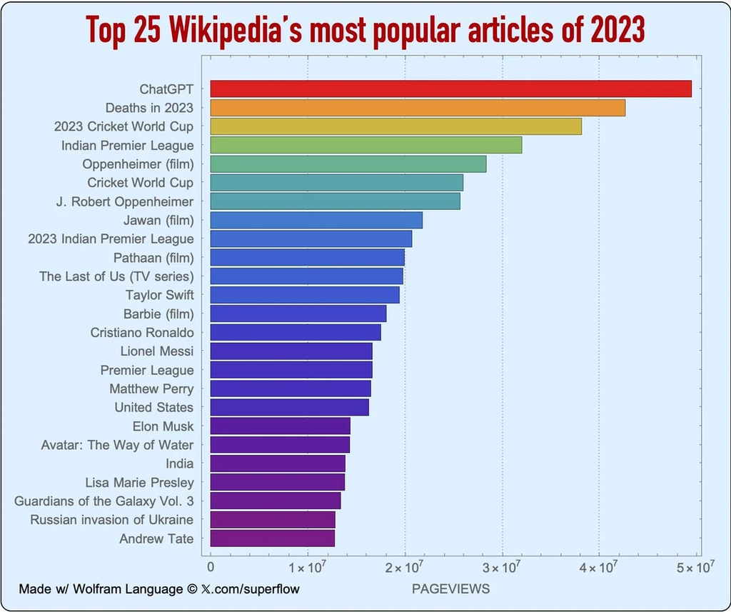

## Generative AI: The market

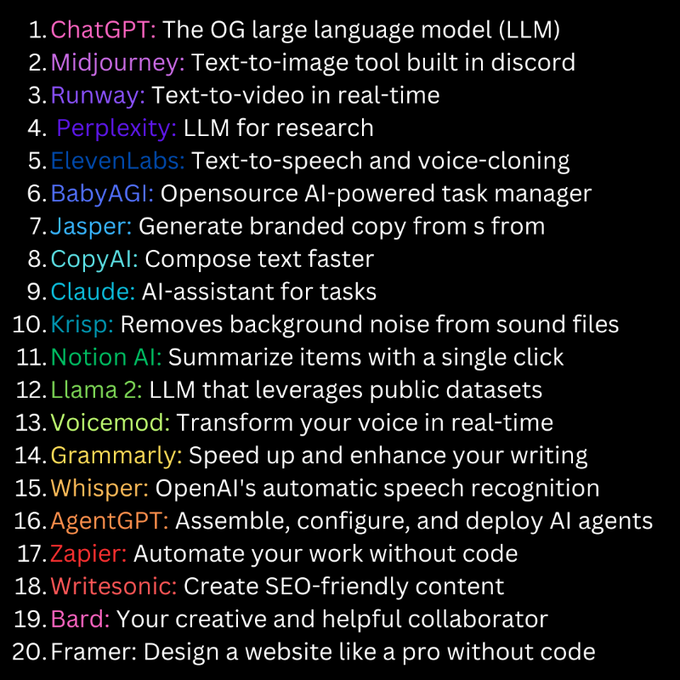

## LLMs: How they work

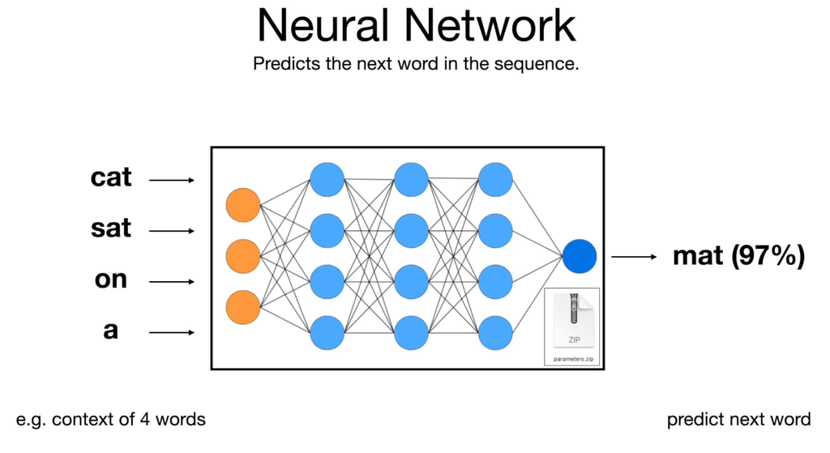

## Training the model

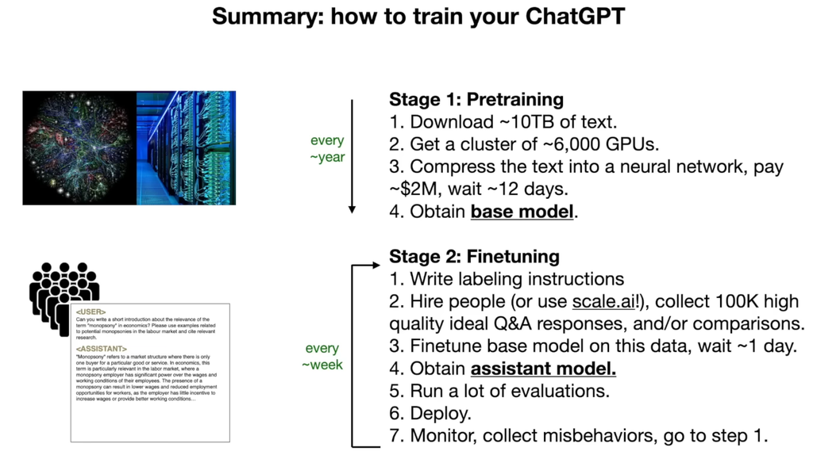

## Fundamentals

- LLMs “dream” content based on their training data (the internet)
- LLMs are to some degree inscrutable and empirical
- You (probably) won’t get the same answer twice
- They will hallucinate (because they dream)

## Prompting

- System Prompt (describes how the model should behave)
  - “System: You are chatGPT, an expert in human resources and recruitment, you understand the need for fair recruitment practices and transparency in candidate selection”
- User Prompt (clearly states what you want the model to do)
  - “User: Given this job description, please devise three questions to ask the candidate and supply model answers”
- You can configure chatGPT with default “custom instructions” depending on your needs.

## Let’s chat!

## Building GPTs

- Configure a purpose - built GPT by prompting (chatGPT 4)
- No code required
- e.g.
  - Dejargonizer
  - Research Assistant

## Future - LLM based Operating Systems?

[figure not shown]

## Risks

[figure not shown]

## Security

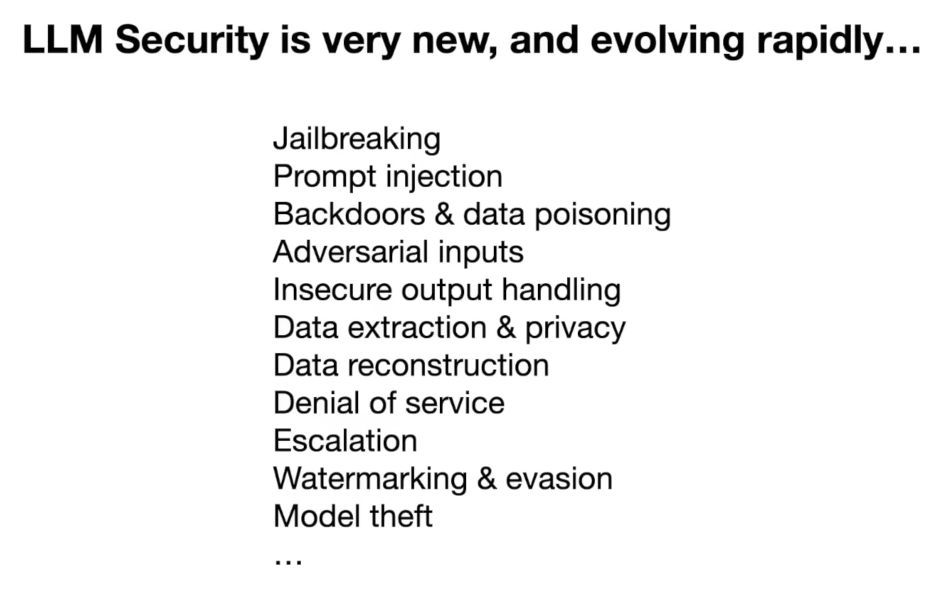

## Further reading

- [Links and Resources](https://raindrop.io/murrayjarvis/llm-essential-42463647)
- New York Times lawsuit
- [Intro to Large Language Models {Andrej Karpathy}](https://www.youtube.com/watch?v=zjkBMFhNj_g)